# Lesson 21

Timothy Luna

9/15/2019

# 3C-L3 Calibrating Cameras

## Intro

We will be calibrating with respect to the 3d world. Last time we solved for a projection equation made up of translation, rotation, and projection matrices. Today we will back out and ignore the structure of $M$ and just consider how to find $M$.

## Calibration Using Known Points

Fundamentally there is the idea of having three-dimensional points in the image and the world and identifying the correspondence between those points in the image and in the world in order to compute the mapping from the scene to the image.

One way to do this is to place a known object in the scene wth a known geometry.

Another way is to do resectioning.

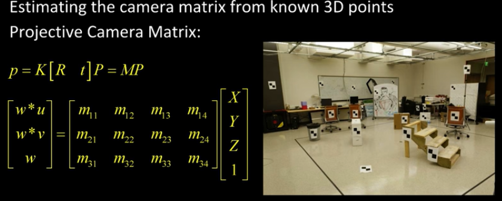

The markers identify known points in the world and, using homogeneous points, given enough points you should be able to calibrate the image!

## Direct Linear Calibration Homogeneous

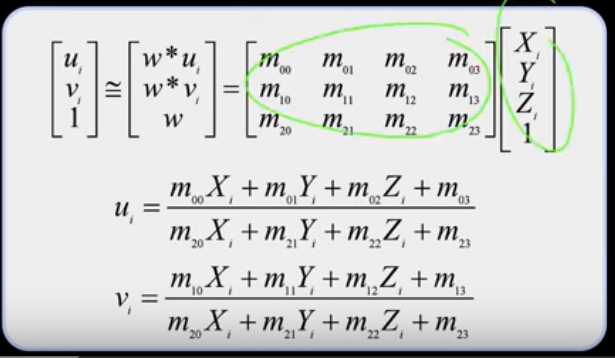

As before the $M$ times the world is the projective equation. There are two versions here and we’re saying that the *far left* is projectively similar to the bit just to the right of it.

The bottom portion is saying that $u_i$ is the inner product of the first row of the $M$ matrix and the world homogeneous coordinate, dvided by the third row inner product wth the same.

We’re going to have to solve for this $M$ matrix using a number of points. How many points? Hmmm…

This linear system of equations can be rewritten in terms of linear algebra.

[figure not shown]

This is now a homogeneous set of equations and can be solved wth singular value decompostion (SVD).

## The SVD Trick

A homogeneous set of equations, when overconstrained, defines a least square problem which can be solved through minimization of $||Am||$.

$m$ is only defined up to scale, and it is arbitrary so we can set it to a unit vector. What is the best unit vector to use?

The eigenvector of $A^T A$ with the *smallest* eigenvalue.

This works when you have six or more points (enough to fix all your degrees of freedom.)

How big is $A$? 2nx12 where n is the number of points.

Solution:

- Find the m that minimizes $||Am||$ subject to $||m||=1$.
- Let $A=UDV^T$ (singular value decomposition, D is diagonal and customarily in decreasing value, U and V are orthogonal)
- Minimizing $||Am||$ is the same as minimizing $||UDV^Tm||$.
- $||UDV^Tm||$ is the same as $||DV^Tm||$ because U is a unit vector. Also $||m||=||V^tm||$. Think of $V$ like a rotation, where it doesn’t change the magnitude.
- Therefore minimize $||DV^T M||$ subject to $||V^Tm|=1$.

Why do the transformation?

- Now let $y = V^T m$, now minimize $||Dy||$ subject to $||y||=1$.
- $D$ is diagonal, with decreasing values, so
- $||Dy||$ minimium is when $y = \begin{bmatrix}0&&0&&...&&0&&1\end{bmatrix}^T$
- So the best y for minimizing is the y seen here!
- Since $y=V^T m$, $m=Vy$. $V$ is orthogonal and thus its transpose is the inverse!
- But because of y this just pulls out the last column in $V$.
- Also, the singular values of $A$ are the square roots of the eigenvalues of $A^T A$ and the columns of $V$ are the eigenvectors.

To recap, given $Am=0$ find the eigenvector of $A^T A$ with the smallest eigenvalue and that is m.

## Direct Linear Calibration Inhomogeneous

In some sense this is easier to understand but not as good.

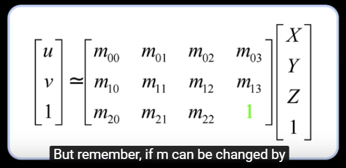

If m can be scaled without effecting the result then it can also be divided by whatever is in the bottom right hand corner to replace the bottom right value with 1.

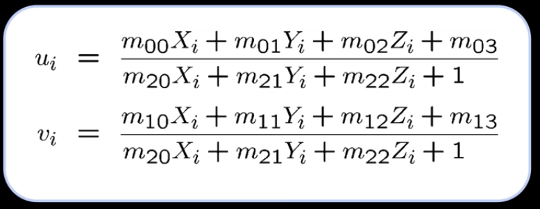

The equations for $u$ and $v_i$ now have terms without variables! THis is now called the *inhomogeneous* solution as a result.

This is bad if $m_{23}$ was supposed to be very close to zero; this can be problematic with respect to numeric stability of the results.

SVD is a one line call in many programmatic implementations.

## Direct Linear Calibration Transformation

The direct method has some advantages:

- It’s very simple to formulate and solve, it could be done on a problem set! You take the points, make A, do SVD, pull out the vector and Bob’s your uncle.

It has disadvantages: * It doesn’t tell you about the camera parameters * It’s approximate (it doesn’t model radial distortion.) * Hard to impose constraints like a known focal length. * It *mostly* doesn’t minimize the correct error function, it minimizes something which is a trick to get toward the answer.

## Geometric Error

So what *is* the right error function.

Suppose you have world points $X_i$ and an image with known locations of the points in the image. When you specify a camera projection M you’re saying you know where the points are supposed to project to the image plane. You want to find the M that minimizes the geometric location error (distance between predicted image locations of points and true locations of points) of the points in the image plane.

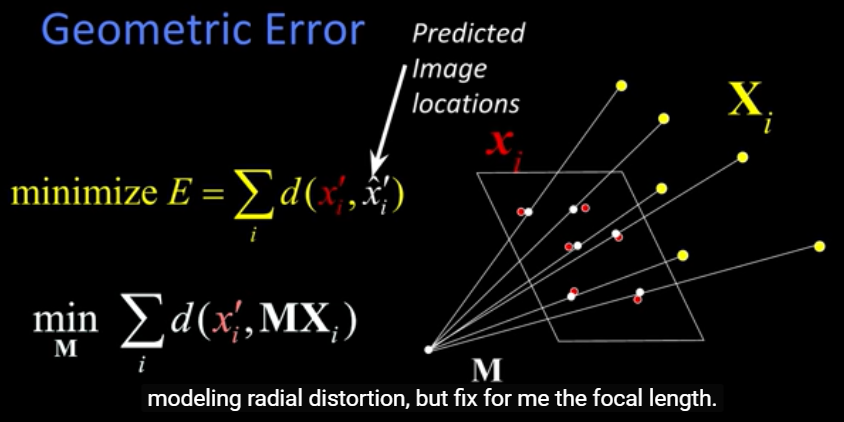

This is a nonlinear minimization and is called the maximum likelihood estimate.

The algorithm:

First compute a linear solution and optionally normalize values to better guarantee numerical stability.

Solve the direct lienar transformation to get a starting point and then perform something like SGD working off the projection geometric error.

Afterwards denormalize if you normalized.

This is the *gold standard* algorithm of calibration.

## The Pure Way

So now we have $M$. $M$ encodes all the parameters, both intrinsic and extrensic. We should be able to get the focal length, camera center, and other things. There are *two* ways, the pure and the easy.

The pure way:

Let $M=[Q|b]$ read as Q and b, *not* Q given b The center $C$ is the null-space of the projection matrix, meaning $MC=0$.

There’s a derivation here.

Let X be somewhere between any point P and C

$X$ (point on the ray) $=\lambda P + (1-\lambda)C$

X is a blend of the two points.

The projection of X is MX, $x=MX=\lambdaMP +(1-\lambda)MC$

All the points on the ray must land at the same point, no matter what lambda is and since it MUST land at lambda MP then MC must equal 0. Rewind to *find the null space*.

## The Easy Way

Suppose you want to do something useful, what’s the easy way?

There’s a formula:

$C = \begin{bmatrix}-Q^{-1}b\\1\end{bmatrix}$

This is the camera center vector in the world frame.

## Multi-plane Calibration

There’s an alternative way of doing calibration and is the industry standard. *Multi-plane calibration*. Take a checkerboard and move it around and you can calibrate the camera with respect to the checkerboard. Given that the squares are swuare, the board is rigid, and is mounted on a plane, you can run some easily available code.

There’s an example of application to robotics.

## End

Next up we’ll move away from rigid calibration with respect to the world and instead will talk about relationships between multiple cameras.